# Mixed Poisson Example with `glmmBoot`

Daniel Flores Agreda

09-05-2020

This code to illustrates the implementation of the bootstrapping methods described in [(Flores-Agreda and Cantoni, Under Review)](https://www.researchgate.net/publication/315768128_Bootstrapping_Generalized_Linear_Mixed_Models_via_a_Weighted_Laplace_Approximation) in a real-data context. Data comes from the example found in [Molenberghs & Verbeke (2006)](https://www.springer.com/gp/book/9780387251448) initially reported by [Faught et. al. (1996)](https://www.ncbi.nlm.nih.gov/pubmed/8649570).

## Analysis

To start performing the analysis, you need:

```r
compile(file = "glmmBoot/src/glmm_rirs.cpp")
dyn.load(dynlib("glmmBoot/src/glmm_rirs"))
```

3. the functions in the file `glmmBoot.R`:

```r
source("glmmBoot/R/glmmBoot.R")
```

4. the dataset `epilepsy.sas7bdat`

```r
epilepsy <- read.sas7bdat(file = "glmmBoot/data/epilepsy.sas7bdat")
```

## Model

The aim of the study was to verify the effects of an new anti-epileptic drug (AED) compared to a placebo on the number of seizures experienced by patients during the study. To do this, consider a mixed Poisson model for the outcome containing two potentially correlated random effects: one for a random intercept and another one for the visit time i.e. $y_{ij}|\mathbf{u}_i\sim \mathcal{P}(\lambda_{ij})$ with:

$$\log(\lambda_{ij}) = \beta_0 + \beta_{1} T_{ij} + \beta_{2}t_{ij} + \beta_{3} T_{ij}t_{ij} + \sigma_{1} u_{i1} + \sigma_{2} u_{i2} t_{ij}$$

where:

- $T_{ij}$ represents the effect of the treatment and
- $t_{ij}$ the visit time.

The variance-covariance structure of the vector of Normal random effects $\mathbf{u}_i = [u_{i1}, u_{i2}]^T$, comprises a correlation coefficient $\rho$ , i.e.

$$\mathbf{D}(\mathbf{\sigma}) = \left[\begin{array}{c c} \sigma_{1}^2 & \rho\sigma_{1}\sigma_{2} \\ \rho\sigma_{1}\sigma_{2} & \sigma_{2}^2 \end{array}\right]$$
.

## Implementation

### `estimate_glmm()`

The function `estimate_glmm()` estimates the model with a `TMB` template using the frame and estimates of objects of class `glmerMod` as starting values. For example:

```r
obj.glmerMod <- lme4::glmer(nseizw~ trt*studyweek + (studyweek|id),
                            family = "poisson",
                            data = epilepsy,
                            control = glmerControl(optimizer = "bobyqa"))
```

for comparison purposes, let us also extract the estimates of this object

A comparison of the estimates yields:

```r
est_lmer %>%
  inner_join(est_tmb, by=("Parameters"), suffix=c(" (glmer)", " (TMB)"))
```

```
##      Parameters Estimates (glmer) Std..Errors (glmer) Estimates (TMB)
## 1   (Intercept)        0.89453458         0.178197278      0.89448691
## 2           trt       -0.24426928         0.253821873     -0.24430693
## 3     studyweek       -0.02714197         0.009853964     -0.02714537
## 4 trt:studyweek        0.01067094         0.013847413      0.01067169
## 5           s_1        1.12719788                  NA      1.12727064
## 6           s_2        0.04871365                  NA      0.04871505
## 7           rho       -0.33392838                  NA     -0.33387741
##   Std..Errors (TMB)
## 1       0.178577727
## 2       0.254354415
## 3       0.009920947
## 4       0.013933258
## 5       0.097487891
## 6       0.005702102
## 7       0.131163744
```

The generation of replicates using Random Weighted Laplace Bootstrap [(Flores-Agreda and Cantoni, Under Review)](https://www.researchgate.net/publication/315768128_Bootstrapping_Generalized_Linear_Mixed_Models_via_a_Weighted_Laplace_Approximation) is carried by the function `bootstrap_glmm()`, with the option `method=rwlb`.

```r
## Bootstrap inference
rwlb_reps <- bootstrap_glmm(obj.glmerMod,
                            B = 1000,
                            method = "rwlb")
```

```
## Bootstrap Replicates via RWLB
```

[output not shown]

[output not shown]

[output not shown]

[output not shown]

[output not shown]

[output not shown]

[output not shown]

[output not shown]

[output not shown]

[output not shown]

[output not shown]

[output not shown]

[output not shown]

[output not shown]

[output not shown]

[output not shown]

[output not shown]

[output not shown]

[output not shown]

[output not shown]

The resulting Bootstrap replicates are stored in an object of the class `glmmBoot`, which can be used to construct

- Estimates of the Parameters: by averaging over the replicates
- Estimates of the Standard Errors: by computing the standard deviations for the replicates and
- Percentile-based Confidence Intervals (CI) with a level of 95%.

## Methods

### `confint()`

produces bootstrap estimates, standard errors and confidence intervals with the `percentile` and `studentized` methods

- Example of the percentile method

```r
rwlb_reps %>%
  confint(bootstrap_type = "percentile")
```

```
## # A tibble: 7 x 5
##   Parameters    Estimate Std_Errors ci_lower ci_upper
##   <fct>            <dbl>      <dbl>    <dbl>    <dbl>
## 1 (Intercept)     0.891     0.150     0.596   1.19
## 2 rho            -0.326     0.170    -0.640  -0.00303
## 3 s_1             1.12      0.137     0.894   1.44
## 4 s_2             0.0478    0.00759   0.0340  0.0639
## 5 studyweek      -0.0273    0.00900  -0.0451 -0.0101
## 6 trt            -0.229     0.256    -0.704   0.297
## 7 trt:studyweek   0.0110    0.0138   -0.0163  0.0366
```

- Example of the studentized method

```r
rwlb_reps %>%
  confint(bootstrap_type = "studentized")
```

```
## # A tibble: 7 x 5
##   Parameters    Estimate Std_Errors ci_lower ci_upper
##   <fct>            <dbl>      <dbl>    <dbl>    <dbl>
## 1 (Intercept)     0.891     0.150     0.610   1.19
## 2 rho            -0.326     0.170    -0.770  -0.0471
## 3 s_1             1.12      0.137     0.841   1.35
## 4 s_2             0.0478    0.00759   0.0320  0.0611
## 5 studyweek      -0.0273    0.00900  -0.0443 -0.00942
## 6 trt            -0.229     0.256    -0.693   0.293
## 7 trt:studyweek   0.0110    0.0138   -0.0163  0.0371
```

### `plot()`

Shows the boxplots of the replicates for all the parameters or a subset with a line describing the TMB estimates

- fixed effect parameters

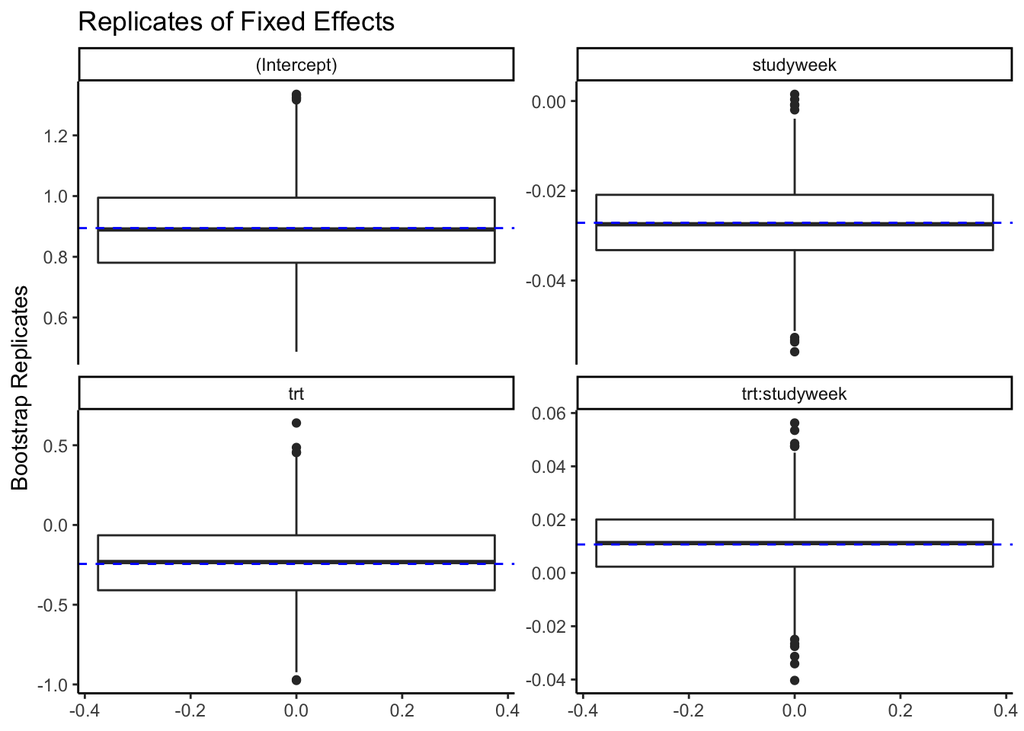

```r
plot(rwlb_reps,
     parm_subset=c("(Intercept)", "trt", "studyweek", "trt:studyweek")) +
  ggtitle("Replicates of Fixed Effects") +
  theme_classic()
```

- variances of random effects

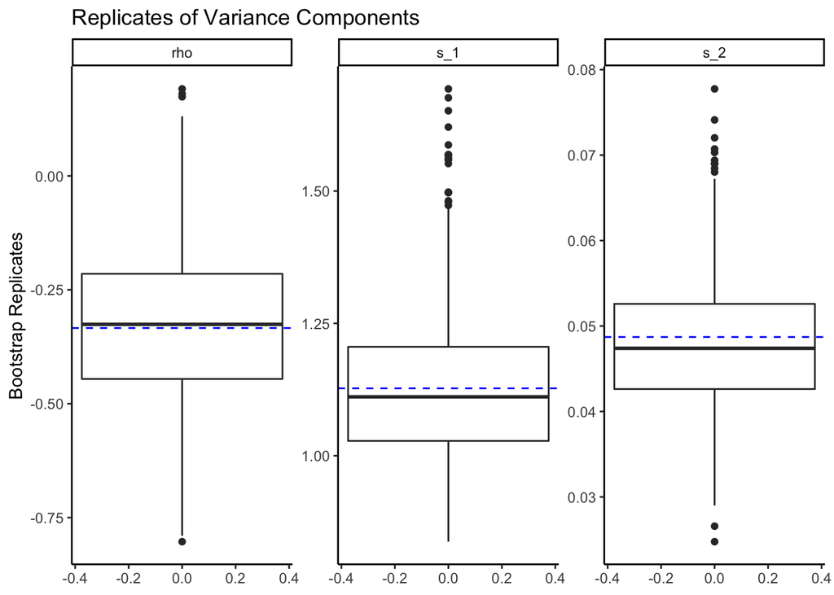

```r
plot(rwlb_reps,
     parm_subset=c("s_1", "s_2", "rho")) +
  ggtitle("Replicates of Variance Components")+theme_classic()
```